# Regressão linear múltipla StackOverflow

```r
library(openintro)
library(tidyverse)
library(tidymodels)
theme_set(theme_bw())

knitr::opts_chunk$set(tidy = FALSE,
                      fig.width = 6,
                      fig.height = 5)
```

*Dados utilizados:*

```r
paises1 = read_csv(here::here("data/participation-per-country.csv"),
                 col_types = "ccddddddddddddccccddc")

glimpse(paises1)
```

```
## Rows: 157
## Columns: 21
## $ site                           <chr> "StackOverflow", "StackOverflow", "Stac~
## $ country                        <chr> "Argentina", "Australia", "Austria", "B~
## $ PDI                            <dbl> 49, 36, 11, 80, 65, 69, 70, 39, 63, 80,~
## $ IDV                            <dbl> 46, 90, 55, 20, 75, 38, 30, 80, 23, 20,~
## $ MAS                            <dbl> 56, 61, 79, 55, 54, 49, 40, 52, 28, 66,~
## $ UAI                            <dbl> 86, 51, 70, 60, 94, 76, 85, 48, 86, 30,~
## $ usuarios                       <dbl> 2798, 12313, 2518, 2558, 4275, 10717, 1~
## $ responderam_prop               <dbl> 0.5357398, 0.6133355, 0.6310564, 0.3928~
## $ perguntaram_prop               <dbl> 0.5210865, 0.5897832, 0.5933280, 0.4757~
## $ editaram_prop                  <dbl> 0.09256612, 0.14699911, 0.14932486, 0.0~
## $ comentaram_prop                <dbl> 0.25339528, 0.33395598, 0.35027800, 0.1~
## $ GNI                            <dbl> NA, 59570, 48160, 840, 44990, 11630, 68~
## $ Internet                       <dbl> 51.0, 79.5, 79.8, 5.0, 78.0, 45.0, 51.0~
## $ EPI                            <dbl> 59.02, NA, 63.21, NA, 61.21, 49.96, NA,~
## $ geo                            <chr> "arg", "aus", "aut", "bgd", "bel", "bra~
## $ four_regions                   <chr> "americas", "asia", "europe", "asia", "~
## $ eight_regions                  <chr> "america_south", "east_asia_pacific", "~
## $ six_regions                    <chr> "america", "east_asia_pacific", "europe~
## $ Latitude                       <dbl> -34.00000, -25.00000, 47.33333, 24.0000~
## $ Longitude                      <dbl> -64.00000, 135.00000, 13.33333, 90.0000~
## $ `World bank income group 2017` <chr> "Upper middle income", "High income", "~
```

## Construa um modelo 1 com a variável responderam_prop com variável de resposta e fluência em inglês da população (EPI), produto interno bruto do país (GNI) e disponibilidade de internet no país como variáveis de explicação.

*Relação entre GNI, EPI, Internet e taxa de resposta:*

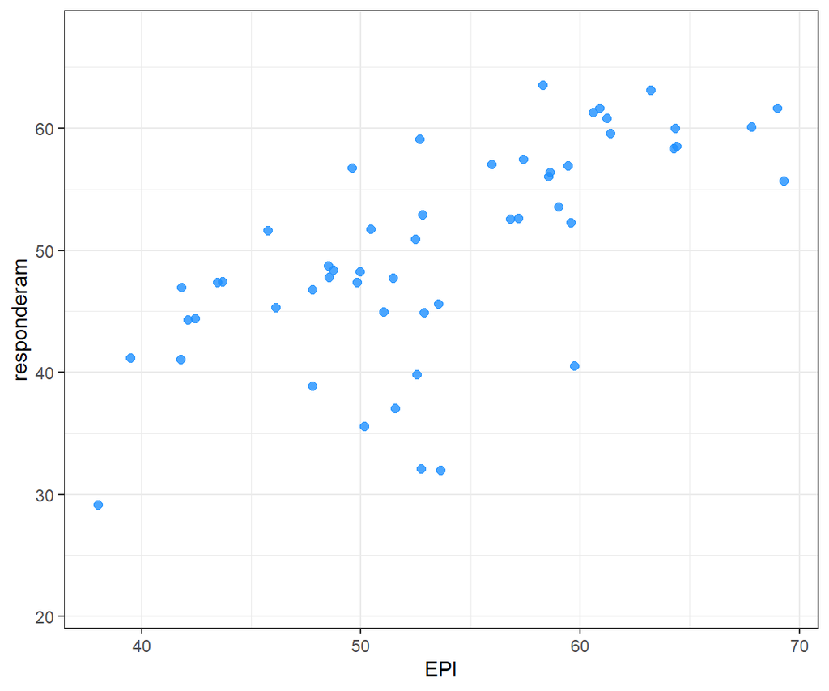

```r
paises = paises1 %>%
    filter(site == "StackOverflow")

responderam = paises$responderam_prop * 100


paises %>%
    ggplot(aes(x = EPI, y = responderam)) +
    geom_point(color = "dodgerblue", size = 2, alpha = .8)
```

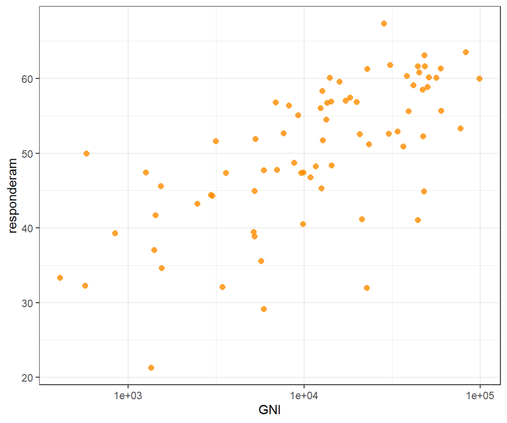

```r
paises %>%
    ggplot(aes(x = GNI, y = responderam)) +
    geom_point(color = "darkorange", size = 2, alpha = .8) +
    scale_x_log10()
```

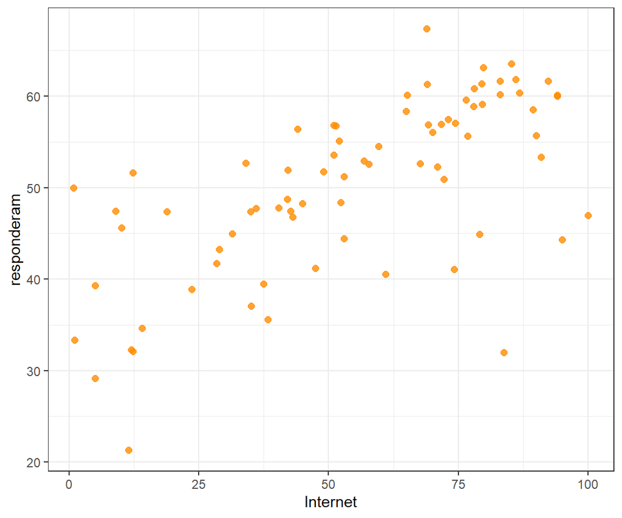

```r
paises %>%
    ggplot(aes(x = Internet, y = responderam)) +
    geom_point(color = "darkorange", size = 2, alpha = .8)
```

*Relação entre GNI transformado, EPI, Internet e taxa de resposta transformada:*

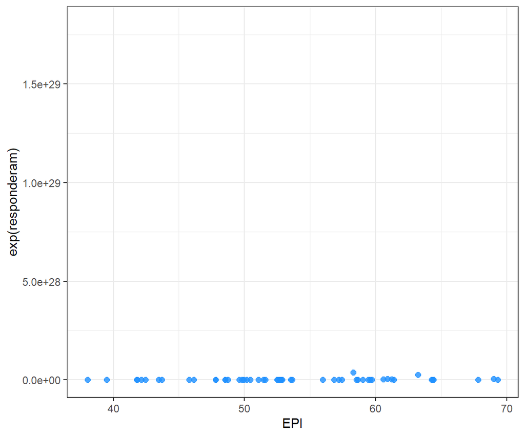

```r
responderam = paises$responderam_prop * 100

paises %>%
    ggplot(aes(x = EPI, y = exp(responderam))) +
    geom_point(color = "dodgerblue", size = 2, alpha = .8)
```

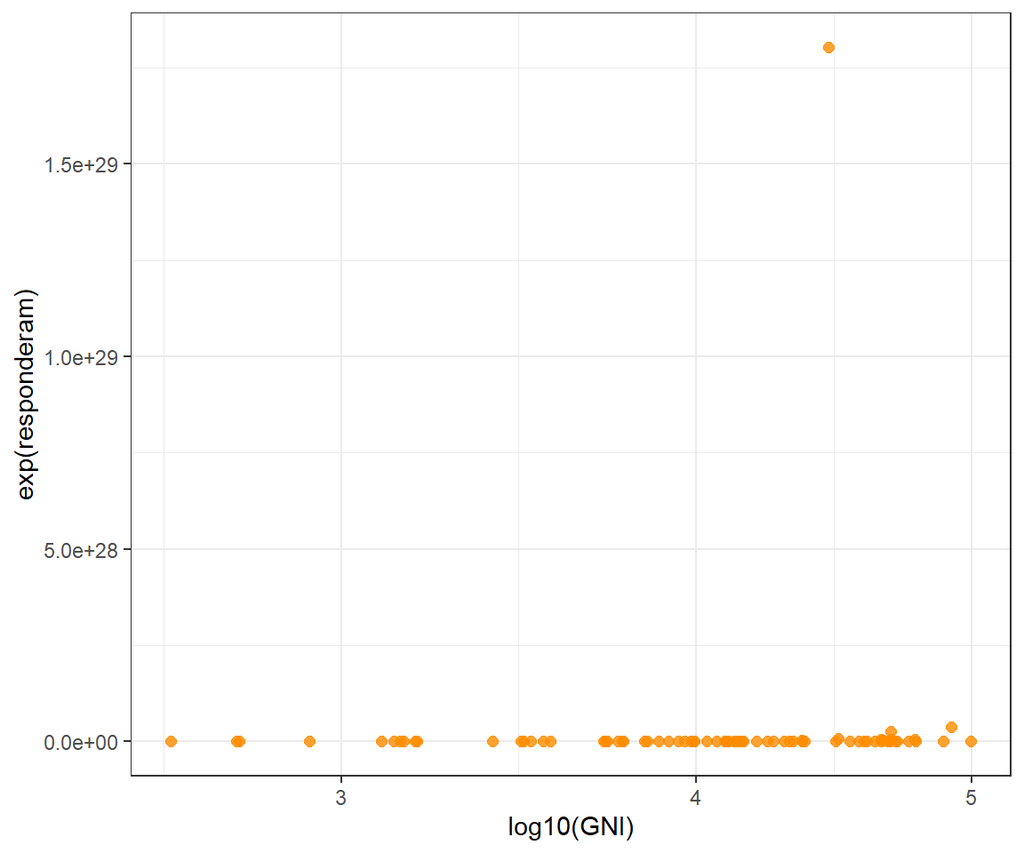

```r
paises %>%
    ggplot(aes(x = log10(GNI), y = exp(responderam))) +
    geom_point(color = "darkorange", size = 2, alpha = .8) +
    scale_x_log10()
```

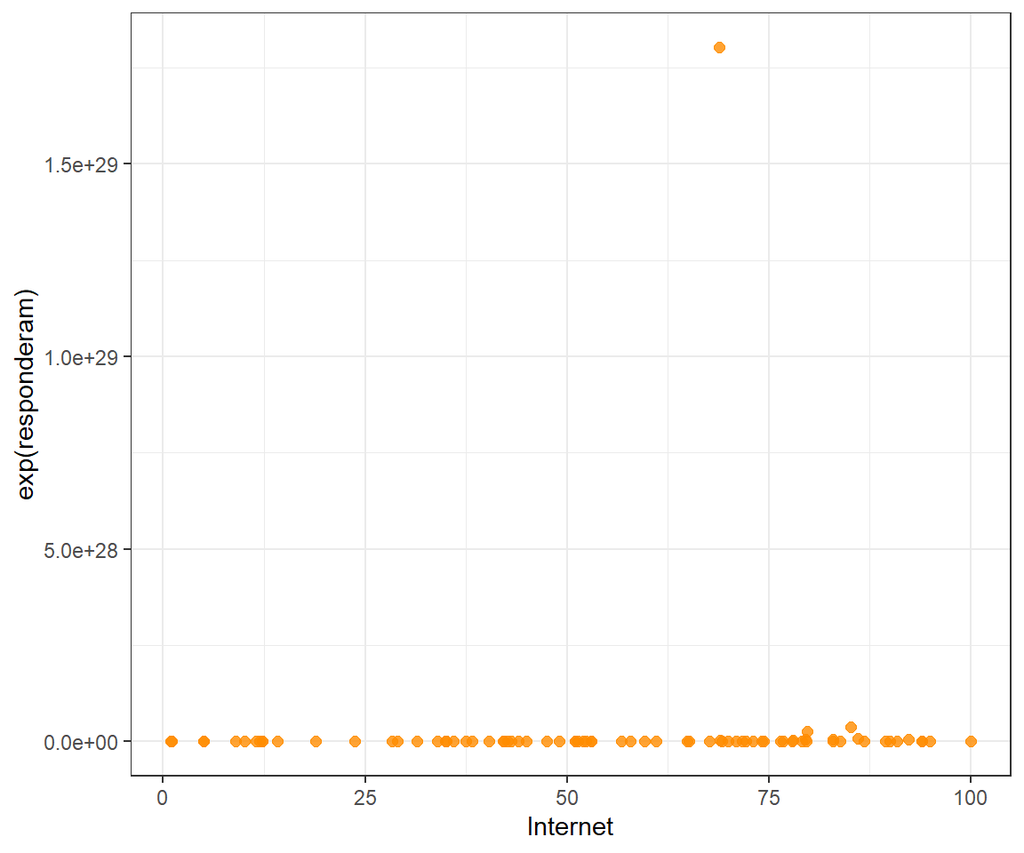

```r
paises %>%
    ggplot(aes(x = Internet, y = exp(responderam))) +
    geom_point(color = "darkorange", size = 2, alpha = .8)
```

```r
# e^responderam = b0 + b1*EPI
# responderam = log(b0 + b1*EPI)


m1 = lm(
    exp(responderam_prop) ~ EPI + log10(GNI) + Internet,
    data = paises
)
tidy(m1, conf.int = T)
```

```
## # A tibble: 4 x 7
##   term        estimate std.error statistic   p.value conf.low conf.high
##   <chr>          <dbl>     <dbl>     <dbl>     <dbl>    <dbl>     <dbl>
## 1 (Intercept) 0.839     0.184        4.55  0.0000401  0.468     1.21
## 2 EPI         0.00892   0.00239      3.74  0.000524   0.00411   0.0137
## 3 log10(GNI)  0.0716    0.0509       1.41  0.166     -0.0308    0.174
## 4 Internet    0.000749  0.000989     0.757 0.453     -0.00124   0.00274
```

```r
glance(m1)
```

```
## # A tibble: 1 x 12
##   r.squared adj.r.squared  sigma statistic      p.value    df logLik   AIC   BIC
##       <dbl>         <dbl>  <dbl>     <dbl>        <dbl> <dbl>  <dbl> <dbl> <dbl>
## 1     0.555         0.525 0.0987      18.7 0.0000000507     3   46.0 -82.1 -72.6
## # ... with 3 more variables: deviance <dbl>, df.residual <int>, nobs <int>
```

**A regressão linear múltipla foi utilizada para analisar a relação entre taxa de pessoas que responderam alguma pergunta no StackOverflow e o EPI, GNI e disponibilidade de internet no país. Um modelo no formato responderam = log(0.83 + 0.008xEPI + 0.07xlog10(GNI) + 0.0007xInternet) explica 55,49% da variância da variável de resposta (R^2 = 0.5549). O aumento de 1% das variáveis de explicação produz um aumento de 0.008 no EPI (IC 95% [0.004; 0.013]) mais um aumento de 0.07 do valor do log do GNI (IC 95% [-0.03; 0.17]) e mais 0.0007 no da Internet (IC 95% [-0.001; 0.0027]), no valor esperado da taxa de resposta. O efeito observado aparentemente pode ter alguma relevância, com valor de acréscimo de baixo à médio. Porém nota-se que os valores de confiança assumem valores negativos e positivos para as variáveis do log do GNI e da Internet, o que pode tornar o efeito destas inconclusivo, neste caso apenas o EPI teria algum efeito sobre a taxa de reposta.**

## Construa um modelo 2 que além das variáveis do modelo 1 tem também o IDV. Esse é um modelo que considera uma variável de cultura. Comparando o modelo 2 com o modelo 1, o que podemos afirmar sobre o efeito do individualismo no comportamento das pessoas de diferentes países no stackoverflow? Há um efeito relevante? O modelo é mais explicativo do que sem a variável relacionada a cultura?

*Relação entre IDV e taxa de resposta:*

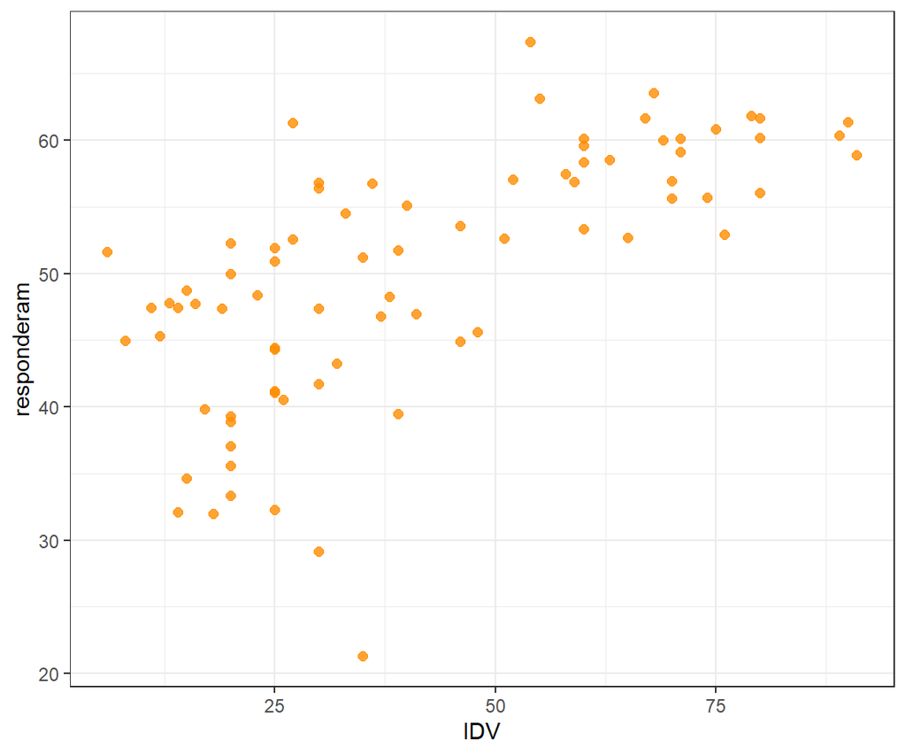

```r
responderam = paises$responderam_prop * 100

paises %>%
    ggplot(aes(x = IDV, y = responderam)) +
    geom_point(color = "darkorange", size = 2, alpha = .8)
```

*Relação entre IDV e taxa de resposta transformada:*

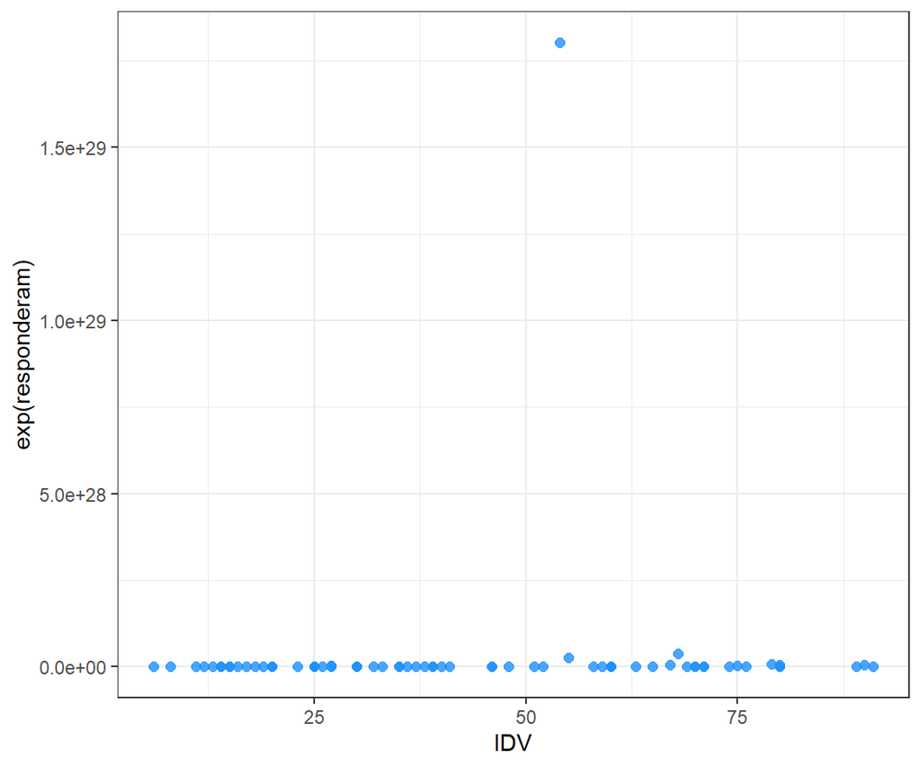

```r
responderam = paises$responderam_prop * 100

paises %>%
    ggplot(aes(x = IDV, y = exp(responderam))) +
    geom_point(color = "dodgerblue", size = 2, alpha = .8)
```

```r
# e^responderam = b0 + b1*EPI
# responderam = log(b0 + b1*EPI)


m2 = lm(
    exp(responderam_prop) ~ EPI + log10(GNI) + Internet + IDV,
    data = paises
)
tidy(m2, conf.int = T)
```

```
## # A tibble: 5 x 7
##   term        estimate std.error statistic    p.value  conf.low conf.high
##   <chr>          <dbl>     <dbl>     <dbl>      <dbl>     <dbl>     <dbl>
## 1 (Intercept) 1.01      0.191        5.30  0.00000352  0.627      1.40
## 2 EPI         0.00622   0.00255      2.43  0.0191      0.00107    0.0114
## 3 log10(GNI)  0.0506    0.0493       1.02  0.311      -0.0489     0.150
## 4 Internet    0.000346  0.000959     0.361 0.720      -0.00159    0.00228
## 5 IDV         0.00210   0.000902     2.33  0.0243      0.000287   0.00392
```

```r
glance(m2)
```

```
## # A tibble: 1 x 12
##   r.squared adj.r.squared  sigma statistic      p.value    df logLik   AIC   BIC
##       <dbl>         <dbl>  <dbl>     <dbl>        <dbl> <dbl>  <dbl> <dbl> <dbl>
## 1     0.604         0.568 0.0941      16.8 0.0000000202     4   48.9 -85.8 -74.4
## # ... with 3 more variables: deviance <dbl>, df.residual <int>, nobs <int>
```